# Reproducible Research Assignment 1

# Analysis with missing data filled in

The strategy I choose to use to fill in the missing data is to use the average step count for that time interval.

First, let’s identify the number of missing data points

```r
sum(is.na(step_data_raw$steps))
```

```
## [1] 2304
```

Second, calculate the average step count by time interval using the cleaned data step from the earlier analysis

```r
avg_step_count_by_interval = aggregate(step_data$steps, by=list(step_data$interval), mean)
names(avg_step_count_by_interval) <- c("Interval", "Avg_Step_Count")
head(avg_step_count_by_interval)
```

```
##   Interval Avg_Step_Count
## 1        0      1.7169811
## 2        5      0.3396226
## 3       10      0.1320755
## 4       15      0.1509434
## 5       20      0.0754717
## 6       25      2.0943396
```

Third, take a copy of th raw data set and then fill in the missing values with th average step count by time interval

```r
step_data_filled = step_data_raw
for( i in unique(step_data_filled[is.na(step_data_filled$steps),'interval'])) {
  step_data_filled[is.na(step_data_filled$steps) & step_data_filled$interval == i,'steps'] =
    avg_step_count_by_interval[avg_step_count_by_interval$Interval == i,'Avg_Step_Count']
}
head(step_data_filled)
```

```
##       steps       date interval
## 1 1.7169811 2012-10-01        0
## 2 0.3396226 2012-10-01        5
## 3 0.1320755 2012-10-01       10
## 4 0.1509434 2012-10-01       15
## 5 0.0754717 2012-10-01       20
## 6 2.0943396 2012-10-01       25
```

Last, let’s check to see if all the missing data points have been filled.

```r
sum(is.na(step_data_filled$steps))
```

```
## [1] 0
```

# Histogram Total Step Count by Day with the Missing Values Filled-in

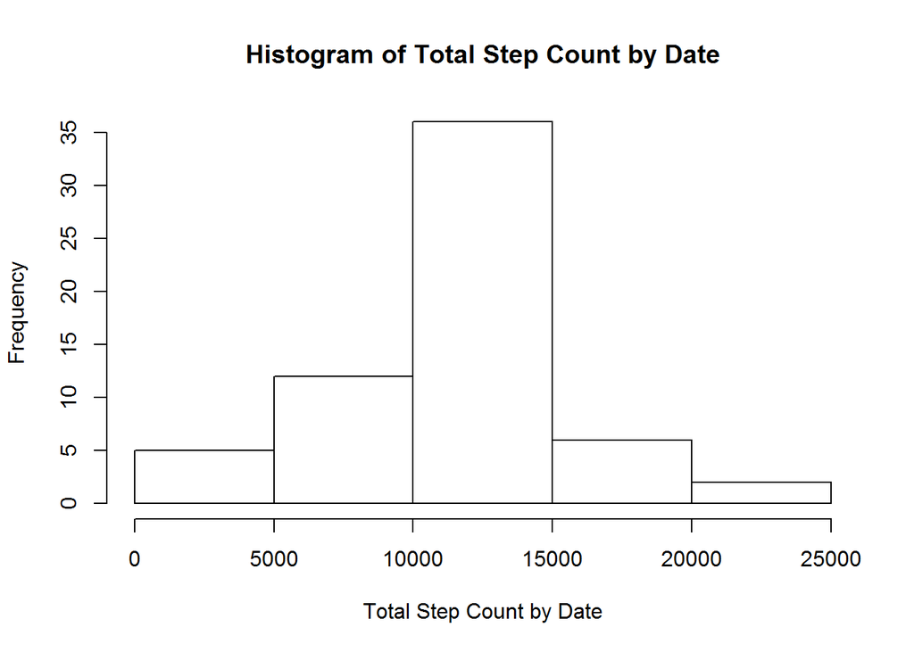

```r
total_step_count = aggregate(step_data_filled$steps, by=list(step_data_filled$date), sum)
names(total_step_count) <- c("Date", "Total_Step_Count")
hist(total_step_count$Total_Step_Count, main="Histogram of Total Step Count by Date",
     xlab="Total Step Count by Date")
```

# Mean and Median for Total Step Count by Day

```r
paste("The mean of the Total Step Count is",
      mean(total_step_count$Total_Step_Count),
      sep=" ")
```

```
## [1] "The mean of the Total Step Count is 10766.1886792453"
```

```r
paste("The median of the Total Step Count is",
      median(total_step_count$Total_Step_Count),
      sep=" ")
```

```
## [1] "The median of the Total Step Count is 10766.1886792453"
```

# Missing-DataFrame vs. Filled-in-Dataframe

With missing data, the mean and median were 10766.19 and 10765 respectivly. While for the data-filled-in dataset, the mean and median 10766.19 and 10766.19. As one might expect, filing in the missing values with averages by time interval causes the total step count to trend more towards the first mean and median. This can be seen in the histogram as well. The second plot is much more centered around the mean.

# Weekday vs. Weekend Analysis

Using the dataset with the filled in missing values, we will now compare the weekday step activity against weekend step activity

First, let’s change the datatype of the date column to a data object

```r
step_data_filled$date = as.Date(step_data_filled$date, '%Y-%m-%d')
head(step_data_filled)
```

```
##       steps       date interval
## 1 1.7169811 2012-10-01        0
## 2 0.3396226 2012-10-01        5
## 3 0.1320755 2012-10-01       10
## 4 0.1509434 2012-10-01       15
## 5 0.0754717 2012-10-01       20
## 6 2.0943396 2012-10-01       25
```

```r
step_data_filled$is_weekend= factor(weekdays(step_data_filled$date) %in% c('Monday', 'Tuesday', 'Wednesday', 'Thursday', 'Friday'),
       levels=c('TRUE', 'FALSE'), labels=c("Weekday", "Weekend"))
```

Third, aggregate the dataframe by interval then by weekday and take the mean.

```r
avg_stp_count_by_interval_weekday = aggregate(step_data_filled$steps,
              by=list(step_data_filled$interval,
                      step_data_filled$is_weekend), mean)
names(avg_stp_count_by_interval_weekday) <- c("interval", "weekday", "avg_step")
```

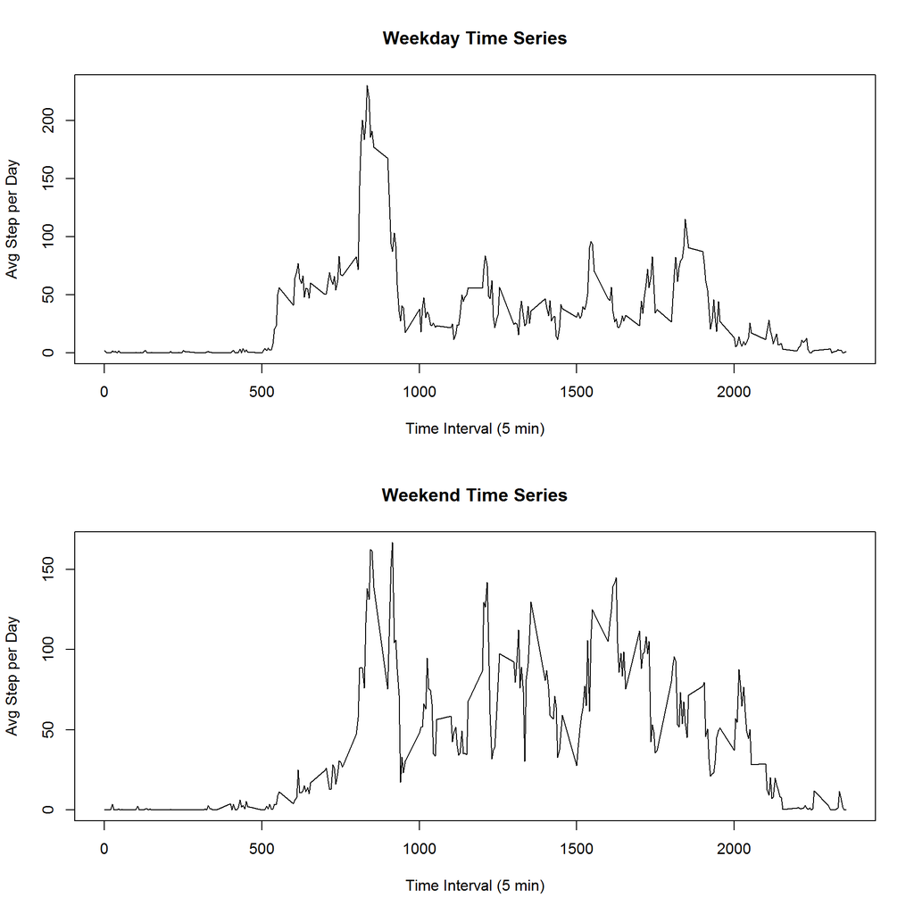

```r
par(mfrow=c(2,1))
plot(avg_stp_count_by_interval_weekday[avg_stp_count_by_interval_weekday$weekday ==
                                         'Weekday',c('interval','avg_step')],
     type="l",
     main="Weekday Time Series",
     xlab="Time Interval (5 min)",
     ylab="Avg Step per Day")

plot(avg_stp_count_by_interval_weekday[avg_stp_count_by_interval_weekday$weekday ==
                                         'Weekend',c('interval','avg_step')],
     type="l",
     main="Weekend Time Series",
     xlab="Time Interval (5 min)",
     ylab="Avg Step per Day")
```